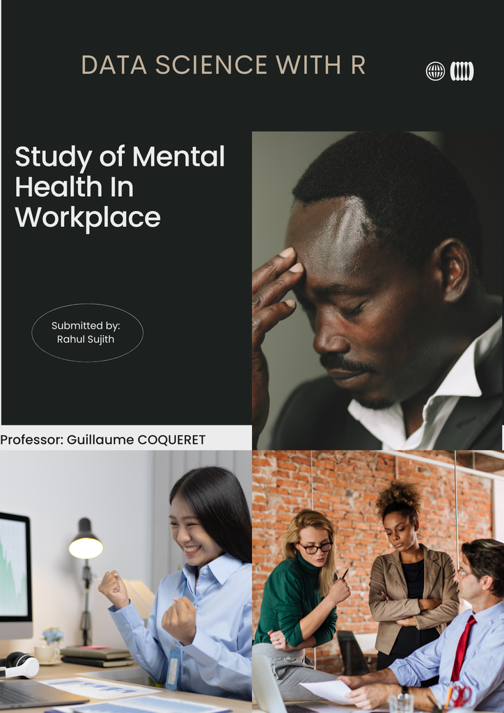

# **MY DASHBOARD**

(https://rahulsujith.shinyapps.io/MentalHealthDashboard/)

The application contains a dashboard with multiple tabs, including home, visualizations, conclusions, and data. It has various visualizations based on age, gender, country, and tech company status. The user can also filter the data based on age, gender, and country. The dashboard provides information about the total number of employees, countries, employees seeking help, and employees undergoing treatment.

The code is primarily focused on creating the user interface (UI) and server components of the Shiny application. The UI is constructed using shinydashboard, shinydashboardPlus, and shinythemes packages, which provide a clean and modern look for the dashboard. The server component of the Shiny app is responsible for generating the visualizations and handling user input.

The visualizations include bar charts displaying the number of employees seeking help from different age groups, seeking help by gender, the treatment ratio in tech and non-tech companies, and the treatment ratio based on the family history of mental illness.

The conclusions tab summarizes the main findings from the visualizations, and the data tab displays the cleaned dataset used for the analysis.

Overall, this Shiny application aims to provide insights into mental health in the workplace and allows users to interactively explore the data.

# **STORY**

The COVID-19 pandemic has had a profound impact on all aspects of our lives, including our mental health. As a former employee in the tech industry, I personally saw the effects of the lockdown on my colleagues and friends, who struggled with mental health issues during that time. This experience sparked my interest in understanding how the mental health of employees is affected in the workplace.

I wanted to dive deeper and uncover the stories behind the statistics, to understand the experiences of employees who are struggling with their mental health. To do this, I obtained a dataset from Kaggle that contains information about the mental health of employees in various countries, including their age, gender, country of residence, and their experiences in the workplace.

With this data, I set out on a journey to understand the complexities of mental health in the workplace, and to uncover the underlying factors that contribute to it. I discovered that mental health issues are prevalent not just in the tech industry, but across all industries, and that they can be influenced by a wide range of factors, such as family history, workplace relationships, and access to treatment.

I also found that the COVID-19 pandemic has had a significant impact on the mental health of employees, as many have struggled with isolation, stress, and uncertainty. However, despite these challenges, many employees have found the strength and support to seek help for their mental health issues, and have taken steps to improve their well-being.

In conclusion, my analysis of this data set has shown me that mental health is a complex and multifaceted issue, and that it requires a holistic approach to address. By understanding the experiences and perspectives of employees, employers can provide better support for their mental health and well-being, and create a more inclusive and supportive workplace for all

# **STEPS FOLLOWED**

The following steps were followed in the creation of the dashboard:

1. Data Cleaning: The raw data was cleaned and processed to remove any inconsistencies and irrelevant information.
2. Data Manipulation: The cleaned data was then used to generate various summary statistics and filter the data based on user inputs.
3. Dashboard Design: The dashboard layout was designed using Shiny, Shiny Dashboard, and other relevant R libraries.
4. Data Visualization: Relevant graphs and plots were created using ggplot2, hrbrthemes, and other visualization libraries.
5. Dashboard Interactivity: User interactivity was added to the dashboard to allow users to filter data based on their preferences.

# **DASHBOARD LAYOUT**

The dashboard consists of the following sections:

1. Header: The header contains the title “Mental Health in the Workplace” and a link to my(creator’s) LinkedIn profile and there is also a user icon to display te username.
2. Sidebar: The sidebar contains navigation menus for different sections of the dashboard, including “Home,” “Visualizations,” “Conclusions,” and “Data.”
3. Body: The dashboard body contains different tabs for each of the sections mentioned in the sidebar.

The code for dashboard is created using the dashboardPage() function from the shinydashboard package. The header is created using the dashboardHeader() function, while the sidebar is created using the dashboardSidebar() function. The body is created using the dashboardBody() function, which contains the different tabs for each section.

The code for dashboard also includes custom styling using the tags$style() function, which sets the background color, box style, and other customization options for the dashboard. The different visualizations are created using plotOutput() and renderPlot() functions, while the table displaying the cleaned dataset is created using the DTOutput() and renderDT() functions from the DT package.

# **DASHBOARD TABS**

1. Home: The Home tab provides an overview of the dashboard, including the purpose of the dashboard, the info boxes with key statistics, an introduction to mental health in the workplace, and a summary of the analysis journey.
2. Visualizations: The Visualizations tab contains interactive charts and plots that allow users to analyze mental health data based on age, gender, country, and whether the individual works in a technology company. The visualizations are dynamically updated based on user inputs.
3. Conclusions: The Conclusions tab summarizes the findings and insights derived from the visualizations. The conclusions highlight trends and patterns observed in the data, such as age group differences, gender differences, and the impact of family history on mental health treatment.
4. Data: The Data tab displays the cleaned dataset in a table format, allowing users to view and explore the data used in the visualizations.

# **CONCLUSION**

By building a shiny app to analyze Mental Health in workplace, I was not only able to enhance the proficiency in R and shiny, but also gained valuable skills in data visualization and communication.The Mental Health in the Workplace Dashboard provides valuable insights into mental health trends and patterns across various demographics and industries. By understanding these trends, employers and employees can better address mental health issues in the workplace and create a more supportive and inclusive environment.